# TSRethinking9 Structural vector autoregressive models

### 1.2.2 Model estimation - with standard form of Cholesky decomposition

Remark: - This ordering is consistent with macroeconomic theory and often applied in a closed-economy setting. - Instead of using the linear cycle, we’re going to use the natural logarithm of GDP. This would imply that we would need to include a deterministic trend in the model, to account for this time trend.

```r
data <- cbind(y, pi, i)
colnames(data) <- c("y", "pi", "i")
info.var <- VARselect(data, lag.max = 12, type = "both")
info.var$selection
```

```
## AIC(n)  HQ(n)  SC(n) FPE(n)
##     12      1      1      1
```

```r
# we will choose VAR(1)

# We will estimate the reduced-form VAR and recover structural-form
# and most importantly we need to add deterministic time trend and a constant in this model type = "both" and the exogenous dummies
var.est1 <- VAR(data, p = 1, type = "both", season = NULL, exogen = dum)
summary(var.est1)
```

```
##
## VAR Estimation Results:
## =========================
## Endogenous variables: y, pi, i
## Deterministic variables: both
## Sample size: 71
## Log Likelihood: 391.079
## Roots of the characteristic polynomial:
##  0.91 0.818 0.3308
## Call:
## VAR(y = data, p = 1, type = "both", exogen = dum)
##
##
## Estimation results for equation y:
## ==================================
## y = y.l1 + pi.l1 + i.l1 + const + trend + dum90 + dum00
##
##         Estimate Std. Error t value Pr(>|t|)
## y.l1   0.9319786  0.0376885  24.728  < 2e-16 ***
## pi.l1 -0.0037627  0.0026405  -1.425  0.15901
## i.l1  -0.0131520  0.0045873  -2.867  0.00560 **
## const  0.6517896  0.3413518   1.909  0.06069 .
## trend  0.0003796  0.0003239   1.172  0.24558
## dum90 -0.0015648  0.0049509  -0.316  0.75299
## dum00  0.0158571  0.0048963   3.239  0.00191 **
## ---
## Signif. codes:  0 '***' 0.001 '**' 0.01 '*' 0.05 '.' 0.1 ' ' 1
##
##
## Residual standard error: 0.004636 on 64 degrees of freedom
## Multiple R-Squared: 0.9993,  Adjusted R-squared: 0.9992
## F-statistic: 1.541e+04 on 6 and 64 DF,  p-value: < 2.2e-16
##
##
## Estimation results for equation pi:
## ===================================
## pi = y.l1 + pi.l1 + i.l1 + const + trend + dum90 + dum00
##
##        Estimate Std. Error t value Pr(>|t|)
## y.l1   0.604500   1.609020   0.376  0.70839
```

[output cut: 33 more lines]

```
## F-statistic: 171.3 on 6 and 64 DF,  p-value: < 2.2e-16
##
##
##
## Covariance matrix of residuals:
##             y         pi          i
## y   2.149e-05 -0.0001328  6.141e-05
## pi -1.328e-04  0.0391758 -2.761e-04
## i   6.141e-05 -0.0002761  5.638e-03
##
## Correlation matrix of residuals:
##          y       pi        i
## y   1.0000 -0.14475  0.17640
## pi -0.1447  1.00000 -0.01858
## i   0.1764 -0.01858  1.00000
```

#### 1.2.2.1 SVAR

Note the coefficients clearly show that we have included both a time trend and a constant, while the variance-covariance of the residuals shows that we have included covariance terms in the reduced-form model.

- set-up the matrix for the contemporaneous coefficients (Restriction)

Using Cholesky decomposition on the matrix of contemporaneous parameters: - Only shocks to output can shift output contemporaneously. a[1, 2], a[1, 3] = 0 - Only shocks to output and inflation can shift inflation contemporaneously. a[2, 3] = 0 - All shocks can affect the interest rate contemporaneously.

To code this appropriately we need to insert zeros for restrictions and NA in all those places that would not pertain to a restriction. Hence,

```r
a.mat <- diag(3)
diag(a.mat) <- NA
a.mat[2, 1] <- NA
a.mat[3, 1] <- NA
a.mat[3, 2] <- NA
print(a.mat)
```

```
##      [,1] [,2] [,3]
## [1,]   NA    0    0
## [2,]   NA   NA    0
## [3,]   NA   NA   NA
```

- set-up the matrix for the identification of individual shocks.

In order to separate the effect, we will set covariance position to be 0.

Once again starting with the diagnol matrix, we need to insert zeros into the covariance terms, while the variance for each of the individual shocks is to be retrieved. Hence,

```r
b.mat <- diag(3)
diag(b.mat) <- NA
print(b.mat)
```

```
##      [,1] [,2] [,3]
## [1,]   NA    0    0
## [2,]    0   NA    0
## [3,]    0    0   NA
```

```r
svar.one <- SVAR(var.est1, Amat = a.mat, Bmat = b.mat, max.iter = 10000,
    hessian = TRUE) # if this model is just identified then there will be a warning, we can close it by adding `irtest = F`
svar.one
```

```
##
## SVAR Estimation Results:
## ========================
##
##
## Estimated A matrix:
##         y        pi i
## y   1.000  0.000000 0
## pi  6.180  1.000000 0
## i  -2.874 -0.002696 1
##
## Estimated B matrix:
##           y     pi       i
## y  0.004636 0.0000 0.00000
## pi 0.000000 0.1958 0.00000
## i  0.000000 0.0000 0.07391
```

The results would suggest that both matrices have the correct functional form.

### 1.2.3 Impulse response functions

The first of these considers the response of interest rates to an individual interest rate shock.

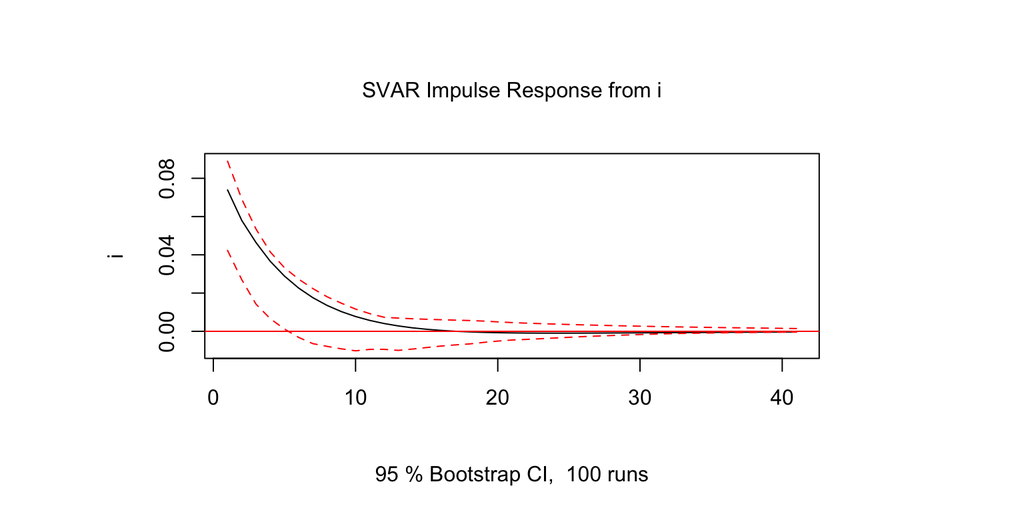

```r
one.int <- irf(svar.one, response = "i", impulse = "i",
    n.ahead = 40, ortho = TRUE, boot = TRUE)
plot(one.int)
```

Note that as is to be expected, interest rate shocks are relatively persistent.

The response of output to an interest rate shock could then be generated.

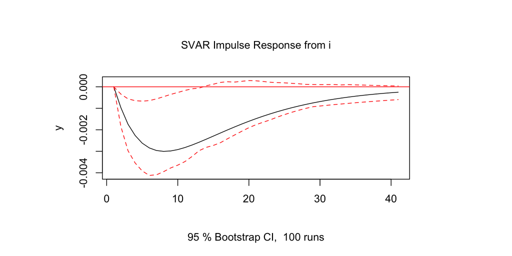

```r
one.gdp <- irf(svar.one, response = "y", impulse = "i",
    n.ahead = 40, ortho = TRUE, boot = TRUE)
plot(one.gdp)
```

Then lastly we consider the effect of the interest rate shock on inflation.

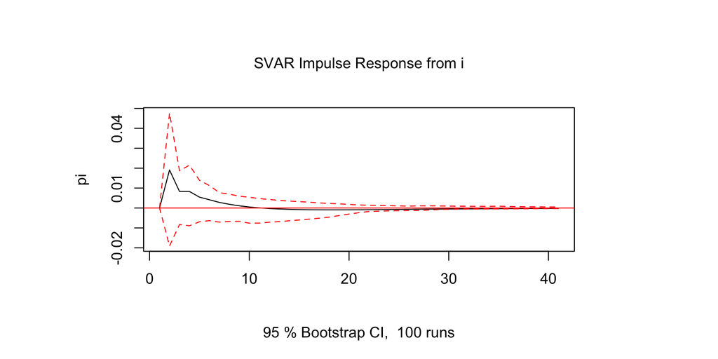

```r
one.inf <- irf(svar.one, response = "pi", impulse = "i",
    n.ahead = 40, ortho = TRUE, boot = TRUE)
plot(one.inf)
```

Hence, these impulse response functions suggest that a contractionary monetary policy shock:

- increases the interest rate temporarily
- has a temporary negative effect on GDP
- has a temporary positive effect on inflation